# Demonstration of Spacetime

Date created: August 1, 2022  
Author: P. Alexander Burnham

**Load Python Environment**

```r
#load the reticulate package
library(reticulate)

# activate environment
use_condaenv(condaenv = "myCondaEnvironment", conda = "auto", required = FALSE)
```

**Check Python Version**

```python
import platform

# make sure python 3.9 is loaded
print(platform.python_version())
```

```
## 3.9.5
```

**Load Spacetime Files**

```python
from spacetime.input.readData import read_data
from spacetime.scale.rasterAlign import raster_align
from spacetime.scale.rasterTrim import raster_trim
from spacetime.objects.fileObject import file_object
from spacetime.operations.cubeSmasher import cube_smasher
from spacetime.operations.makeCube import make_cube
from spacetime.operations.loadCube import load_cube
from spacetime.graphics.dataPlot import plot_cube
from spacetime.operations.time import cube_time, return_time, scale_time, select_time
from spacetime.operations.cubeToDataframe import cube_to_dataframe
import matplotlib.pyplot as plt
```

**Aim:** Here we will explore a common use case that Spacetime addresses. We will be merging different files, each containing a different year of data that need to be aligned, trimmed and stacked into a spatiotemporal cube. We will run each line of Spacetime code and then explore what it has done to the files for illustration purposes. Much more code is depicted here than would be necessary in a script for processing data, although it is always good to check that things are going to plan as you write lines of code. We will write the final object out as a cleaned data cube that could than be read back into Spacetime for further processing, sent to other users for additional analyses, or used in other programs for plotting, modeling, analyses etc.

### Stacking two differently formatted files

```python
# make script
# make notebook
# make demo video
# load all to page

# read files
data = ["walkthrough_data/LULC_1995.tif", "walkthrough_data/India_cropped-area_1km_2016.tif"]

# load data
fo = read_data(data)

# let's query some attributes of this file object
fo.number_of_bands() # check number of bands
```

```
## [1, 1]
```

```python
fo.extract_epsg_code() # check the epsg codes
```

```
## ['EPSG:32644', 'EPSG:4326']
```

```python
fo.get_raster_dimensions() # check the raster dimensions
```

```
## [(29484, 33555), (2373, 3269)]
```

```python
fo.pixel_size() # check pixel size
```

```
## [100.0, 0.008868160000000002]
```

```python
fo.get_nodata_value() # check no data values
```

```
## [127.0, -1.7e+308]
```

**Let’s plot the two files in the object and see what they look like**

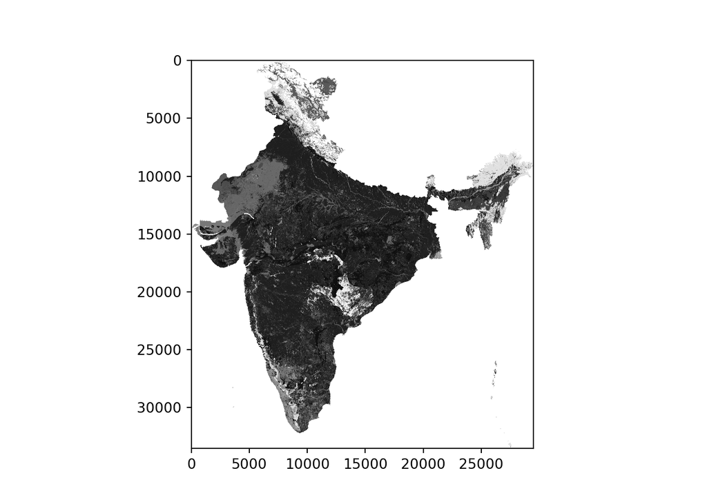

```python
# Get the array data
arrays = fo.get_raster_data()

# plot file 1
plt.imshow(arrays[0], vmin=0, vmax=17, cmap='gray')
plt.show()

# plot file 2
```

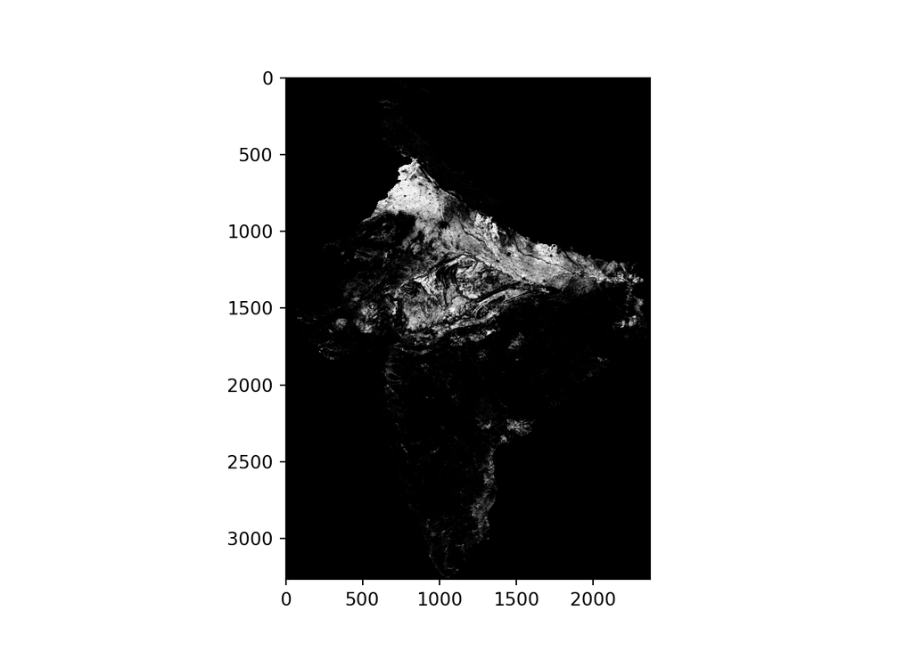

```python
plt.imshow(arrays[1], vmin=0, vmax=100, cmap='gray')
plt.show()
```

**Now we will align the files**

```python
# let's align the files (hand set the resolution, srs, and no data values)
alignedFO = raster_align(data=fo, resolution=0.08, SRS=4326, noneVal=127)

# let's query some attributes after aligning:
alignedFO.extract_epsg_code() # check the epsg codes
```

```
## ['EPSG:4326', 'EPSG:4326']
```

```python
alignedFO.get_raster_dimensions() # check the raster dimensions
```

```
## [(409, 383), (264, 363)]
```

```python
alignedFO.pixel_size() # check pixel size
```

```
## [0.08, 0.08]
```

```python
alignedFO.get_nodata_value() # check no data values
```

```
## [127.0, 127.0]
```

**Let’s plot the two files in the object again**

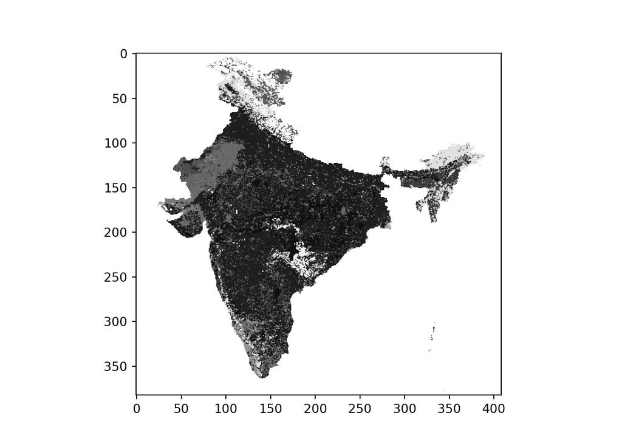

```python
# Get the array data
arrays = alignedFO.get_raster_data()

# plot file 1
plt.imshow(arrays[0], vmin=0, vmax=17, cmap='gray')
plt.show()

# plot file 2
```

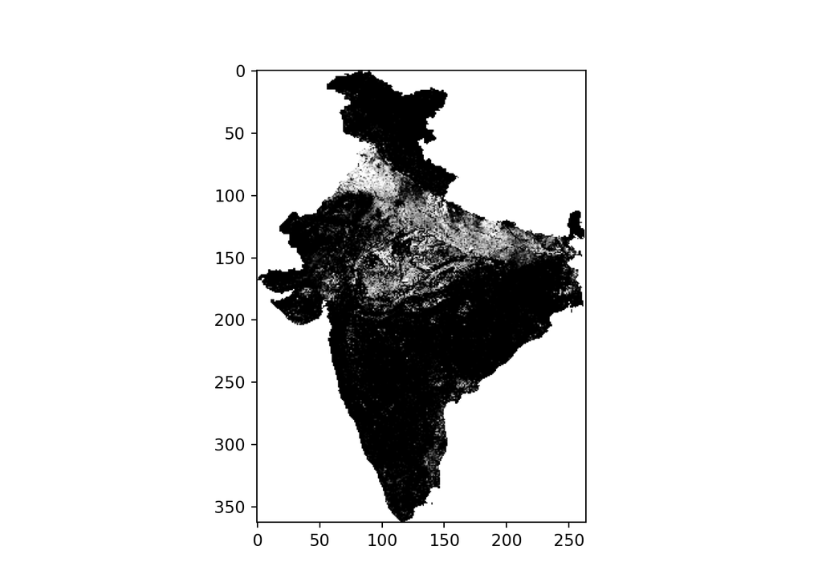

```python
plt.imshow(arrays[1], vmin=0, vmax=100, cmap='gray')
plt.show()
```

**The files are aligned but have different bounding boxes**

```python
# here we use an intersection to trim the files. "union", pairs of corners and shape files are also options
trimmedFO = raster_trim(alignedFO, method = "intersection")

# check the raster dimensions to ensure we have a successful intersection
trimmedFO.get_raster_dimensions()
```

```
## [(264, 363), (264, 363)]
```

**Finally, we will export this cleaned file object as a cube object**

```python
# make a time object
yearObj = cube_time(start="1995", length=2, scale = "year", skips = 21)

# set files as the variables and bands within each file as time variables
cube = make_cube(data = trimmedFO, fileName = "indiaCube.nc4", organizeFiles = "filestotime", organizeBands="bandstotime", timeObj = yearObj)

## let's look at the structure of the cube
cube.get_raster_data()
```

```
<xarray.DataArray (lat: 363, lon: 264, time: 2)>
array([[[127., 127.],
        [127., 127.],
        [127., 127.],
        ...,
        [127., 127.],
        [127., 127.],
        [127., 127.]],

       [[127., 127.],
        [127., 127.],
        [127., 127.],
        ...,
        [127., 127.],
        [127., 127.],
        [127., 127.]],

       [[127., 127.],
        [127., 127.],
        [127., 127.],
        ...,
...
        ...,
        [127., 127.],
        [127., 127.],
        [127., 127.]],

       [[127., 127.],
        [127., 127.],
        [127., 127.],
        ...,
        [127., 127.],
        [127., 127.],
        [127., 127.]],

       [[127., 127.],
        [127., 127.],
        [127., 127.],
        ...,
        [127., 127.],
        [127., 127.],
        [127., 127.]]], dtype=float32)
Coordinates:
  * lon      (lon) float32 68.08 68.16 68.24 68.32 ... 88.88 88.96 89.04 89.12
  * lat      (lat) float32 37.12 37.04 36.96 36.88 36.8 ... 8.4 8.32 8.24 8.16
  * time     (time) datetime64[ns] 1995-12-31 2016-12-31
```

### Plotting the cube using spacetime

**Plot temporal summary**

```python
# plot a summary using mean over time
plot_cube(cube=cube, type="time_series", showPlot=True,summary="mean")
```

[output not shown]

```
##      timeChar       time    lat   lon      value
## 0  1995-12-31 1995-12-31  22.64  78.6   4.684217
## 1  2016-12-31 2016-12-31  22.64  78.6  11.707617
```

**Plot spatial data**

```python
# plot space
plot_cube(cube=cube, type="space", showPlot=True)
```

[output not shown]

```
##           timeChar        lat        lon       time  value
## 0       1995-12-31  37.119999  68.080002 1995-12-31    NaN
## 1       2016-12-31  37.119999  68.080002 2016-12-31    NaN
## 2       1995-12-31  37.119999  68.160004 1995-12-31    NaN
## 3       2016-12-31  37.119999  68.160004 2016-12-31    NaN
## 4       1995-12-31  37.119999  68.239998 1995-12-31    NaN
## ...            ...        ...        ...        ...    ...
## 191659  2016-12-31   8.160000  88.959999 2016-12-31    NaN
## 191660  1995-12-31   8.160000  89.040001 1995-12-31    NaN
## 191661  2016-12-31   8.160000  89.040001 2016-12-31    NaN
## 191662  1995-12-31   8.160000  89.120003 1995-12-31    NaN
## 191663  2016-12-31   8.160000  89.120003 2016-12-31    NaN
##
## [191664 rows x 5 columns]
```